# BSMM-lab-2

BSMM 8740 Fall 2023

Author

Anna Preenu Pappachan Rosily - 110105133

Published

September 29, 2023

```r
library(magrittr)     # the pipe
library(tidyverse)    # for data wrangling + visualization
library(tidymodels)   # for modeling
library(gt)           # for making display tables
library(gtExtras)     # helper functions for beautiful tables
library(DataExplorer)
library(readr)
library(dplyr)
library(tibble)
```

## Setup

Load packages and data:

```r
the_tate <- readr::read_delim("data/the-tate-collection.csv", ";", escape_double = FALSE, trim_ws = TRUE)
the_tate_artists <- readr::read_csv("data/the-tate-artists.csv")
```

## Exercises

### Exercise 1

The `the_tate` dataset has 3342 unique artists who worked from 1545 to 2012. The works were acquired between the years 1823 and 2013.

```r
the_tate |> dplyr::summarize(
  no_artists = n_distinct(artistId),
  max_period_year = max(year, na.rm = TRUE),
  min_period_year = min(year, na.rm = TRUE),
  max_period_acquisitionYear = max(acquisitionYear, na.rm = TRUE),
  min_period_acquisitionYear = min(acquisitionYear, na.rm = TRUE),

)
```

```
# A tibble: 1 × 5
  no_artists max_period_year min_period_year max_period_acquisitionYear
       <int>           <dbl>           <dbl>                      <dbl>
1       3342            2012            1545                       2013
# ℹ 1 more variable: min_period_acquisitionYear <dbl>
```

### Exercise 2

How number of works with missing dates is 5397.

The number of artists whose works have missing dates is 461.

It would require resolving missing year data for only 11 artists to resolve at least 50% of the missing data.

The missing year data likely to be classified as MAR (Missing At Random).

```r
the_tate |> DataExplorer::introduce()
```

```
# A tibble: 1 × 9
   rows columns discrete_columns continuous_columns all_missing_columns
  <int>   <int>            <int>              <int>               <int>
1 69201      20               13                  7                   0
# ℹ 4 more variables: total_missing_values <int>, complete_rows <int>,
#   total_observations <int>, memory_usage <dbl>
```

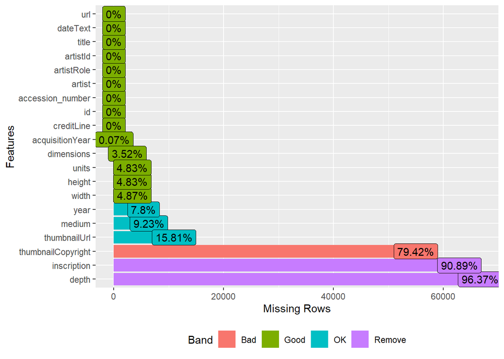

```r
#This shows that there are no missing columns and that there are 219798 missing values
the_tate |> DataExplorer::plot_missing()
```

```r
the_tate |> dplyr::glimpse()
```

```
Rows: 69,201
Columns: 20
$ id                 <dbl> 20400, 20618, 20830, 21086, 21163, 21157, 21153, 21…
$ accession_number   <chr> "P77527", "P77580", "P77612", "P77680", "P77699", "…
$ artist             <chr> "Charlton, Alan", "Artschwager, Richard", "Marden, …
$ artistRole         <chr> "artist", "artist", "artist", "artist", "artist", "…
$ artistId           <dbl> 891, 669, 1578, 2311, 1922, 2170, 2170, 1938, 2146,…
$ title              <chr> "[no title]", "Interior", "[no title]", "Untitled",…
$ dateText           <chr> "1991", "1972", "1971", "1994", "1968", "1994", "19…
$ medium             <chr> "Screenprint on paper", "Screenprint on paper", "Et…
$ creditLine         <chr> "Purchased 1992", "Purchased 1992", "Purchased 1993…
$ year               <dbl> 1991, 1972, 1971, 1994, 1968, 1994, 1994, 1982, 199…
$ acquisitionYear    <dbl> 1992, 1992, 1993, 1994, 1994, 1994, 1994, 1983, 199…
$ dimensions         <chr> "image: 362 x 362 mm", "image: 715 x 1043 mm", "ima…
$ width              <dbl> 362, 715, 370, 582, 1044, 380, 383, 1147, 544, 585,…
$ height             <dbl> 362, 1043, 603, 584, 681, 356, 362, 760, 641, 418, …
$ depth              <dbl> NA, NA, NA, NA, NA, NA, NA, NA, NA, NA, NA, NA, NA,…
$ units              <chr> "mm", "mm", "mm", "mm", "mm", "mm", "mm", "mm", "mm…
$ inscription        <chr> "date inscribed", "date inscribed", "date inscribed…
$ thumbnailCopyright <chr> "© Alan Charlton", "© ARS, NY and DACS, London 2014…
$ thumbnailUrl       <chr> "https://data.opendatasoft.com/api/datasets/1.0/the…
$ url                <chr> "http://www.tate.org.uk/art/artworks/charlton-no-ti…
```

```r
# Finding works with missing year data
missing_recs <- the_tate |> filter(is.na(year))
missing_recs_len <- nrow(missing_recs)
missing_recs_len
```

```
[1] 5397
```

```r
#5397 rows have missing data

# Finding number of artists with missing date
the_tate|>dplyr::filter(is.na(year))|>dplyr::distinct(artist)
```

```
# A tibble: 461 × 1
   artist
   <chr>
 1 Burne-Jones, Sir Edward Coley, Bt
 2 Houghton, Arthur Boyd
 3 Jones, George
 4 Poynter, Sir Edward
 5 Varley, John
 6 Stothard, Thomas
 7 Hunt, William Henry
 8 Smetham, James
 9 Keene, Charles Samuel
10 Swan, John Macallan
# ℹ 451 more rows
```

```r
artists_with_missing_date <- the_tate |>
  filter(is.na(year)) |>
  distinct(artist) |>
  nrow()
artists_with_missing_date
```

```
[1] 461
```

```r
# Another way to find the number of works with missing year
artist_missing_year_count <- the_tate|>dplyr::filter(is.na(year)) |>
  group_by(artist) |>
  summarise(missing_year = sum(is.na(year))) |>
  arrange(desc(missing_year)) |>
  as_tibble()
print(artist_missing_year_count)
```

```
# A tibble: 461 × 2
   artist                         missing_year
   <chr>                                 <int>
 1 Jones, George                          1039
 2 Turner, Joseph Mallord William          343
 3 British (?) School                      325
 4 Cozens, Alexander                       209
 5 Dance-Holland, Sir Nathaniel            163
 6 Stothard, Thomas                        158
 7 Flaxman, John                           136
 8 Barlow, Francis                         106
 9 Davis, John Scarlett                     83
10 Hunt, William Henry                      78
# ℹ 451 more rows
```

```r
artists_with_missing_year <- nrow(artist_missing_year_count)
print(artists_with_missing_year)
```

```
[1] 461
```

```r
works_with_missing_year <- sum(is.na(the_tate$year))
print(works_with_missing_year)
```

```
[1] 5397
```

```r
# Number of artist entries to be resolved in order to resolve atleast 50% of the missing data problem
artist_missing_year_count <- artist_missing_year_count |> # Calculate the percentage of missing 'year' values for each artist #
  mutate(percentage = (missing_year / works_with_missing_year) * 100)

artist_missing_year_count <- artist_missing_year_count |>
  mutate(cumulative_percentage = cumsum(percentage)) # Calculate the cumulative percentage of missing 'year' values

artists_to_resolve_50_percent <- min(which(artist_missing_year_count$cumulative_percentage >= 50))
print(artists_to_resolve_50_percent)
```

```
[1] 11
```

### Exercise 3

The artist with the most works in the Tate collection is Turner, Joseph Mallord William.

The artist with the tenth-most works in the Tate collection is Warhol, Andy.

```r
# Finding artist with the most work
artist_with_most_work <- the_tate |> group_by(artist) |> summarize(total_works = n()) |> arrange(desc(total_works)) |> slice(1) |> pull(artist)
artist_with_most_work
```

```
[1] "Turner, Joseph Mallord William"
```

```r
# Turner, Joseph Mallord William is the artist with the most works

# Top ten artists with most works
artist_with_tenth_rank_works <- the_tate |> group_by(artist) |> summarize(total_works = n()) |> arrange(desc(total_works)) |> slice(10) |> pull(artist)
artist_with_tenth_rank_works
```

```
[1] "Warhol, Andy"
```

```r
# Warhol, Andy is the artist ranked 10nth with the most works
```

### Exercise 4

The artist with the greatest number of works in the Tate collection represent 56.9197% of the total number of works

```r
# Getting a glimpse of the data set
the_tate |>dplyr::glimpse()
```

```
Rows: 69,201
Columns: 20
$ id                 <dbl> 20400, 20618, 20830, 21086, 21163, 21157, 21153, 21…
$ accession_number   <chr> "P77527", "P77580", "P77612", "P77680", "P77699", "…
$ artist             <chr> "Charlton, Alan", "Artschwager, Richard", "Marden, …
$ artistRole         <chr> "artist", "artist", "artist", "artist", "artist", "…
$ artistId           <dbl> 891, 669, 1578, 2311, 1922, 2170, 2170, 1938, 2146,…
$ title              <chr> "[no title]", "Interior", "[no title]", "Untitled",…
$ dateText           <chr> "1991", "1972", "1971", "1994", "1968", "1994", "19…
$ medium             <chr> "Screenprint on paper", "Screenprint on paper", "Et…
$ creditLine         <chr> "Purchased 1992", "Purchased 1992", "Purchased 1993…
$ year               <dbl> 1991, 1972, 1971, 1994, 1968, 1994, 1994, 1982, 199…
$ acquisitionYear    <dbl> 1992, 1992, 1993, 1994, 1994, 1994, 1994, 1983, 199…
$ dimensions         <chr> "image: 362 x 362 mm", "image: 715 x 1043 mm", "ima…
$ width              <dbl> 362, 715, 370, 582, 1044, 380, 383, 1147, 544, 585,…
$ height             <dbl> 362, 1043, 603, 584, 681, 356, 362, 760, 641, 418, …
$ depth              <dbl> NA, NA, NA, NA, NA, NA, NA, NA, NA, NA, NA, NA, NA,…
$ units              <chr> "mm", "mm", "mm", "mm", "mm", "mm", "mm", "mm", "mm…
$ inscription        <chr> "date inscribed", "date inscribed", "date inscribed…
$ thumbnailCopyright <chr> "© Alan Charlton", "© ARS, NY and DACS, London 2014…
$ thumbnailUrl       <chr> "https://data.opendatasoft.com/api/datasets/1.0/the…
$ url                <chr> "http://www.tate.org.uk/art/artworks/charlton-no-ti…
```

```r
artist_with_most_works <- the_tate |> group_by(artist) |> summarize(total_works = n()) |> arrange(desc(total_works)) |> slice(1)
artist_with_most_works
```

```
# A tibble: 1 × 2
  artist                         total_works
  <chr>                                <int>
1 Turner, Joseph Mallord William       39389
```

```r
total_no_of_works <- nrow(the_tate)
total_no_of_works
```

```
[1] 69201
```

```r
# Finding the required percentage
perc_represented <- ((artist_with_most_works$total_works)/total_no_of_works)*100
perc_represented
```

```
[1] 56.9197
```

### Exercise 5

There are 23705 duplicate artist-title pairs

```r
library(dplyr)

total_rows <- total_no_of_works

# Select only the columns for artist and title to count distinct combinations
distinct_artist_title_pair <- the_tate |> select(artist,title) |> distinct()

distinct_count <- nrow(distinct_artist_title_pair)

print(total_rows) # Print the total number of unique artists
```

```
[1] 69201
```

```r
print(distinct_count)
```

```
[1] 45496
```

```r
# Finding the number of duplicated artist-title pairs
duplicated_count <- total_rows - distinct_count
print(duplicated_count)
```

```
[1] 23705
```

```r
#23705 duplicate artist-title pairs are present in the dataset
```

### Exercise 6

```r
library(dplyr)
library(tidyr)

the_tate_work_area <- the_tate |> mutate(area_cm2 = width * depth * height)
the_tate_work_area
```

```
# A tibble: 69,201 × 21
      id accession_number artist       artistRole artistId title dateText medium
   <dbl> <chr>            <chr>        <chr>         <dbl> <chr> <chr>    <chr>
 1 20400 P77527           Charlton, A… artist          891 [no … 1991     Scree…
 2 20618 P77580           Artschwager… artist          669 Inte… 1972     Scree…
 3 20830 P77612           Marden, Bri… artist         1578 [no … 1971     Etchi…
 4 21086 P77680           Francis, Ma… artist         2311 Unti… 1994     Monot…
 5 21163 P77699           Self, Colin  artist         1922 Powe… 1968     Scree…
 6 21157 P77704           Woodrow, Bi… artist         2170 [ind… 1994     Linoc…
 7 21153 P77708           Woodrow, Bi… artist         2170 Iron  1994     Linoc…
 8 21210 P77731           Sherman, Ci… artist         1938 Unti… 1982     Photo…
 9 21271 P77738           Wilding, Al… artist         2146 [no … 1994     Etchi…
10 21405 P77748           Struth, Tho… artist         2339 Vico… 1988     Photo…
# ℹ 69,191 more rows
# ℹ 13 more variables: creditLine <chr>, year <dbl>, acquisitionYear <dbl>,
#   dimensions <chr>, width <dbl>, height <dbl>, depth <dbl>, units <chr>,
#   inscription <chr>, thumbnailCopyright <chr>, thumbnailUrl <chr>, url <chr>,
#   area_cm2 <dbl>
```

```r
selected_work <- the_tate_work_area |> select(artist,title,area_cm2) |> drop_na()
selected_work
```

```
# A tibble: 2,489 × 3
   artist                title                             area_cm2
   <chr>                 <chr>                                <dbl>
 1 Brock, Sir Thomas     Eve                              368725000
 2 Morland, George       Cowherd and Milkmaid              59248764
 3 Lanteri, Edouard      Bust of Alfred Stevens            79137630
 4 Thornycroft, Sir Hamo Sketch for ‘Artemis’               2331280
 5 Maillol, Aristide     Torso of the Monument to Blanqui 439808904
 6 Warhol, Andy          Self-Portrait Strangulation        2430864
 7 Kounellis, Jannis     Untitled (Hanging Knife)          22136700
 8 Kounellis, Jannis     Untitled (Hair)                   41076000
 9 Ruscha, Edward        The Final End                    249698400
10 Koons, Jeff           Bourgeois Bust - Jeff and Ilona  514199000
# ℹ 2,479 more rows
```

```r
# Finding the artist with largest work
sorted_work <- selected_work |> arrange(area_cm2)
largest_areawork <- sorted_work |> slice_head(n = 1)
largest_areawork$artist
```

```
[1] "Gaudier-Brzeska, Henri"
```

```r
# Finding the artist with smallest work
smallest_areawork <- sorted_work |> slice_tail(n=1)
smallest_areawork$artist
```

```
[1] "Head, Tim"
```

```r
# Area of the smallest work
smallest_areawork$area_cm2
```

```
[1] 387610426325
```

### Exercise 7

Join the tables `the_tate` and `the_tate_artists` using `dplyr::left_join`, assigning the result to the variable `the_tate` . Drop rows with `NA` gender values and then group by gender. Show the resulting table.

```r
library(dplyr)
the_tate <- left_join(the_tate, the_tate_artists, by = c("artist" = "name"))
the_tate
```

```
# A tibble: 69,319 × 28
    id.x accession_number artist       artistRole artistId title dateText medium
   <dbl> <chr>            <chr>        <chr>         <dbl> <chr> <chr>    <chr>
 1 20400 P77527           Charlton, A… artist          891 [no … 1991     Scree…
 2 20618 P77580           Artschwager… artist          669 Inte… 1972     Scree…
 3 20830 P77612           Marden, Bri… artist         1578 [no … 1971     Etchi…
 4 21086 P77680           Francis, Ma… artist         2311 Unti… 1994     Monot…
 5 21163 P77699           Self, Colin  artist         1922 Powe… 1968     Scree…
 6 21157 P77704           Woodrow, Bi… artist         2170 [ind… 1994     Linoc…
 7 21153 P77708           Woodrow, Bi… artist         2170 Iron  1994     Linoc…
 8 21210 P77731           Sherman, Ci… artist         1938 Unti… 1982     Photo…
 9 21271 P77738           Wilding, Al… artist         2146 [no … 1994     Etchi…
10 21405 P77748           Struth, Tho… artist         2339 Vico… 1988     Photo…
# ℹ 69,309 more rows
# ℹ 20 more variables: creditLine <chr>, year <dbl>, acquisitionYear <dbl>,
#   dimensions <chr>, width <dbl>, height <dbl>, depth <dbl>, units <chr>,
#   inscription <chr>, thumbnailCopyright <chr>, thumbnailUrl <chr>,
#   url.x <chr>, id.y <dbl>, gender <chr>, dates <chr>, yearOfBirth <dbl>,
#   yearOfDeath <dbl>, placeOfBirth <chr>, placeOfDeath <chr>, url.y <chr>
```

```r
the_tate <- the_tate |> filter(!is.na(gender))
the_tate
```

```
# A tibble: 68,619 × 28
    id.x accession_number artist       artistRole artistId title dateText medium
   <dbl> <chr>            <chr>        <chr>         <dbl> <chr> <chr>    <chr>
 1 20400 P77527           Charlton, A… artist          891 [no … 1991     Scree…
 2 20618 P77580           Artschwager… artist          669 Inte… 1972     Scree…
 3 20830 P77612           Marden, Bri… artist         1578 [no … 1971     Etchi…
 4 21086 P77680           Francis, Ma… artist         2311 Unti… 1994     Monot…
 5 21163 P77699           Self, Colin  artist         1922 Powe… 1968     Scree…
 6 21157 P77704           Woodrow, Bi… artist         2170 [ind… 1994     Linoc…
 7 21153 P77708           Woodrow, Bi… artist         2170 Iron  1994     Linoc…
 8 21210 P77731           Sherman, Ci… artist         1938 Unti… 1982     Photo…
 9 21271 P77738           Wilding, Al… artist         2146 [no … 1994     Etchi…
10 21405 P77748           Struth, Tho… artist         2339 Vico… 1988     Photo…
# ℹ 68,609 more rows
# ℹ 20 more variables: creditLine <chr>, year <dbl>, acquisitionYear <dbl>,
#   dimensions <chr>, width <dbl>, height <dbl>, depth <dbl>, units <chr>,
#   inscription <chr>, thumbnailCopyright <chr>, thumbnailUrl <chr>,
#   url.x <chr>, id.y <dbl>, gender <chr>, dates <chr>, yearOfBirth <dbl>,
#   yearOfDeath <dbl>, placeOfBirth <chr>, placeOfDeath <chr>, url.y <chr>
```

```r
grouped_data <- the_tate |> group_by(gender)
grouped_data
```

```
# A tibble: 68,619 × 28
# Groups:   gender [2]
    id.x accession_number artist       artistRole artistId title dateText medium
   <dbl> <chr>            <chr>        <chr>         <dbl> <chr> <chr>    <chr>
 1 20400 P77527           Charlton, A… artist          891 [no … 1991     Scree…
 2 20618 P77580           Artschwager… artist          669 Inte… 1972     Scree…
 3 20830 P77612           Marden, Bri… artist         1578 [no … 1971     Etchi…
 4 21086 P77680           Francis, Ma… artist         2311 Unti… 1994     Monot…
 5 21163 P77699           Self, Colin  artist         1922 Powe… 1968     Scree…
 6 21157 P77704           Woodrow, Bi… artist         2170 [ind… 1994     Linoc…
 7 21153 P77708           Woodrow, Bi… artist         2170 Iron  1994     Linoc…
 8 21210 P77731           Sherman, Ci… artist         1938 Unti… 1982     Photo…
 9 21271 P77738           Wilding, Al… artist         2146 [no … 1994     Etchi…
10 21405 P77748           Struth, Tho… artist         2339 Vico… 1988     Photo…
# ℹ 68,609 more rows
# ℹ 20 more variables: creditLine <chr>, year <dbl>, acquisitionYear <dbl>,
#   dimensions <chr>, width <dbl>, height <dbl>, depth <dbl>, units <chr>,
#   inscription <chr>, thumbnailCopyright <chr>, thumbnailUrl <chr>,
#   url.x <chr>, id.y <dbl>, gender <chr>, dates <chr>, yearOfBirth <dbl>,
#   yearOfDeath <dbl>, placeOfBirth <chr>, placeOfDeath <chr>, url.y <chr>
```

### Exercise 8

The annual return in the SPX price in 2020 was -13.985%.

The corresponding price volatility was 34.7%

```r
spx_data <- readr::read_delim("data/SPX_HistoricalData_1692322132002.csv", ",", escape_double = FALSE, trim_ws = TRUE)
spx_data <- spx_data |> mutate(Year = lubridate::year(as.Date(Date, format = "%m/%d/%Y")))

spx_data <- spx_data |> rename("close"=`Close/Last`)

spx_data <- spx_data |> mutate(rd = log(lead(close) / close))

spx_data <- spx_data |> mutate(vard = rd^2)

#summarise the data to group by year #
summary_data <- spx_data |>
  group_by(Year) |>
  summarize(
    Annual_Return = (exp(sum(rd, na.rm = TRUE)) - 1)*100,
    Annual_StdDev = sqrt(sum(vard, na.rm = TRUE))*100,
    .groups = "drop"  # Drop grouping after summary
  )

view(summary_data)
# The annual return in the SPX rpice in 2020 was -13.98510%
# The corresponding price volatility is 34.70043
```

### Exercise 9

The period volatility was _48.77%%

```r
# Calculate period return and period volatility
period_return <- prod(1 + summary_data$Annual_Return) - 1
period_volatility <- sqrt(sum(summary_data$Annual_StdDev^2))

period_return
```

```
[1] 24513798
```

```r
period_volatility
```

```
[1] 48.77949
```

```r
rows_value <- tibble::tibble(
  Year = as.character("Period"),  # Ensuring "Year" is character type
  Annual_Return = period_return,
  Annual_StdDev = period_volatility
)

# Converting the Year column from the earlier table to character type
summary_data <- summary_data |>
  mutate(Year = as.character(Year))

# Combine the new column with the summary_data column from before
summary_data <- bind_rows(summary_data, rows_value)

print(summary_data)
```

```
# A tibble: 7 × 3
  Year   Annual_Return Annual_StdDev
  <chr>          <dbl>         <dbl>
1 2018            13.7          12.1
2 2019           -22.4          12.6
3 2020           -14.0          34.7
4 2021           -21.2          13.2
5 2022            24.1          24.1
6 2023           -12.8          10.7
7 Period    24513798.           48.8
```

```r
# The period volatility is 48.77%
```